# Understand Process Capability

Scroll through this scrollytelling journey to quickly grasp the key differences between Process Capability Indices: Cp, Cpk, Pp, and Ppk.

When we measure something continuous, like weight, length, or assay results,

the values often form a pattern called a normal distribution

And one key property of a normal distribution

is that 99.7% of the data falls within three standard deviations above or below the mean

And to ensure the process that have generated these data is capable

its variation (or spread) must be less than or equal to the allowable specification range

this is what we call

the Pp index

This index compare the actual process performance (the voice of the process) against the specification (the voice of the customer).

But wait!

What’s happen for this index if the data is shift like this ?

Actually, nothing changes—since the data spread remains the same, the Pp index will still be greater than 1, even if all the data points fall outside the specification limits

Consequently, to complement the Pp index, the Ppk index is also used, as it is take into account the mean of data observed

This index compare the half part of the distribution (3s) to the spread between ULS or LSL with the mean of the data.

And as we have both side we make this comparison for each site

and then we take the min

Now suppose, data have been generated in time like this control chart.

We can distinguish between two types of process variability.

the short-term process variability.

This is estimated using the average of the moving range between consecutive values because we make hypothesis that variability between consecutive values come from only equipment or machine variability.

and the long-term process variability

that represent the full variability observed coming from the common categories (People, Methods, Machines, Materials, Measurements and Environment).

The Pp or Ppk indexes used the long-term process variability.

But if we used instead the short-term process variability $s^{MR}$

we obtain the Cp or Cpk indexes

Cp index represent the potential capability index that we would expect

However with other source of variability that can exist we have a process with a Pp index

And finally knowing that Process is never align on the target, customer received products with a process that have a Ppk index

This drop of capability index

is what we call the capability drop

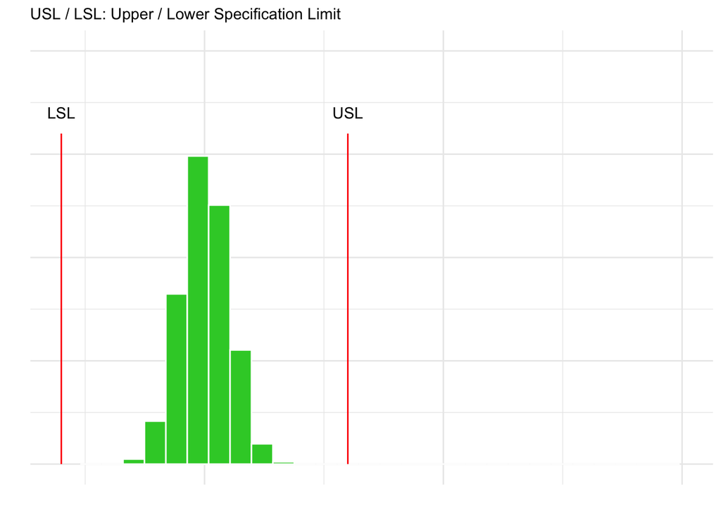

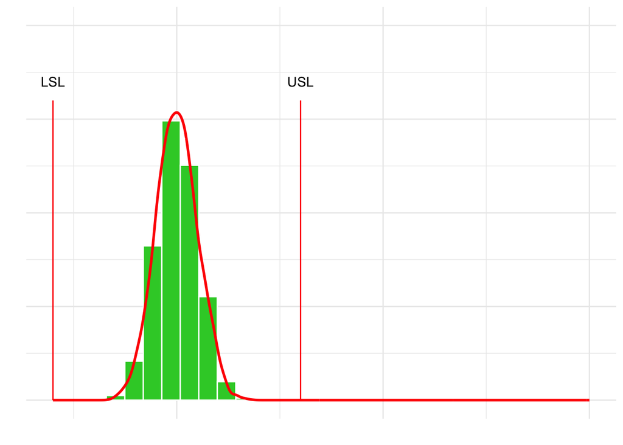

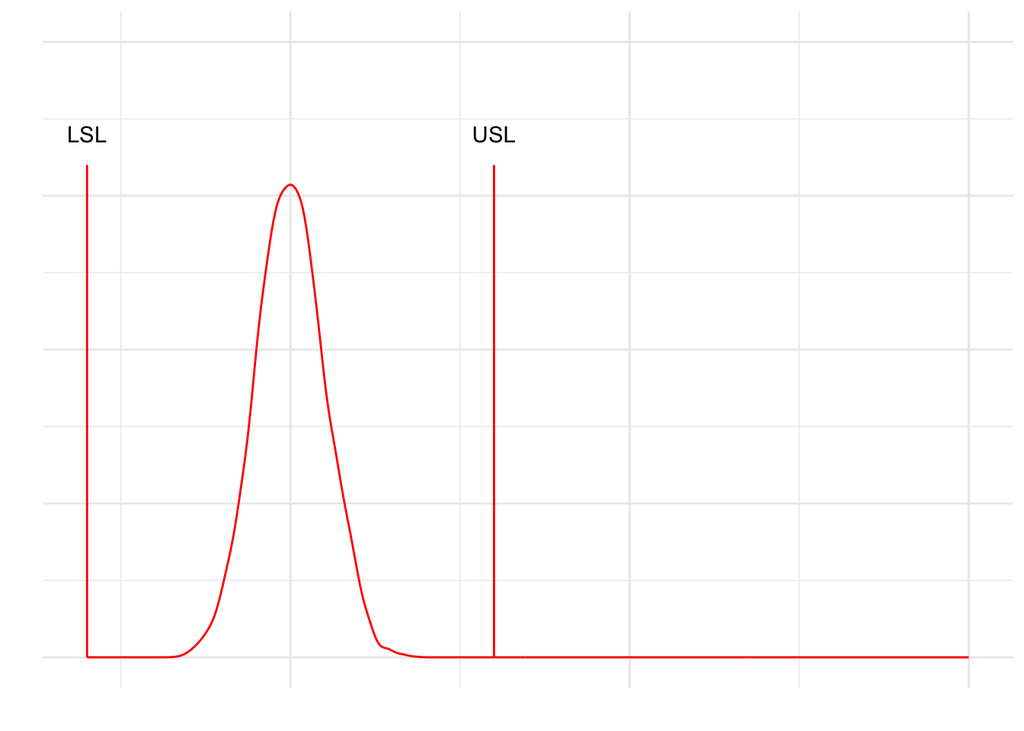

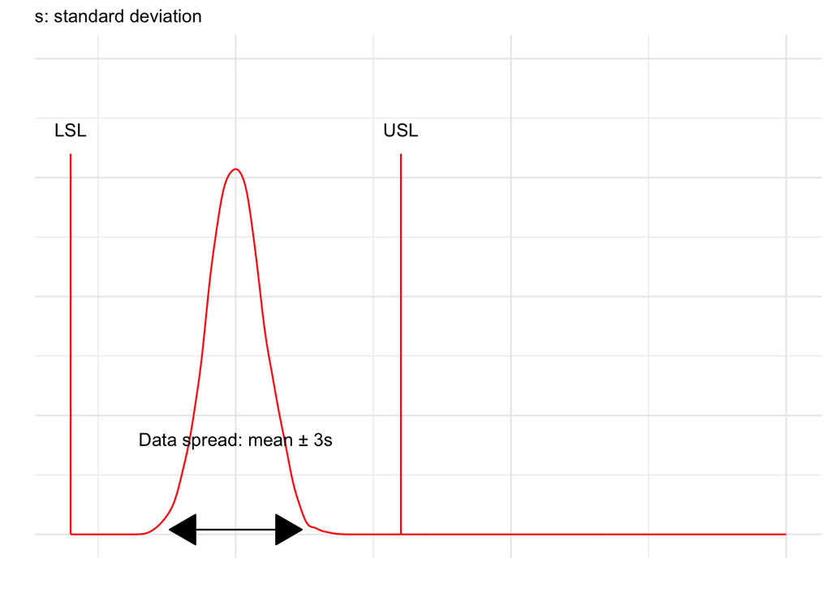

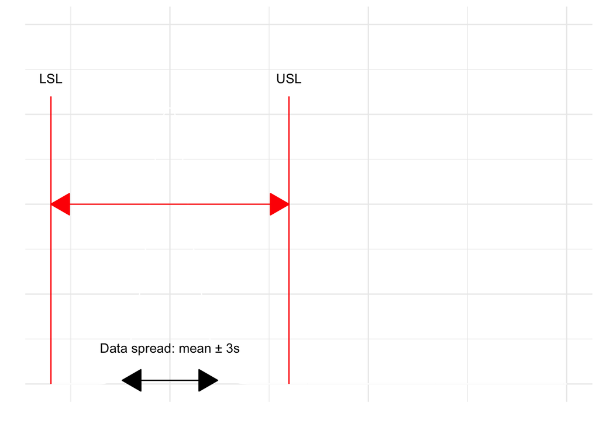

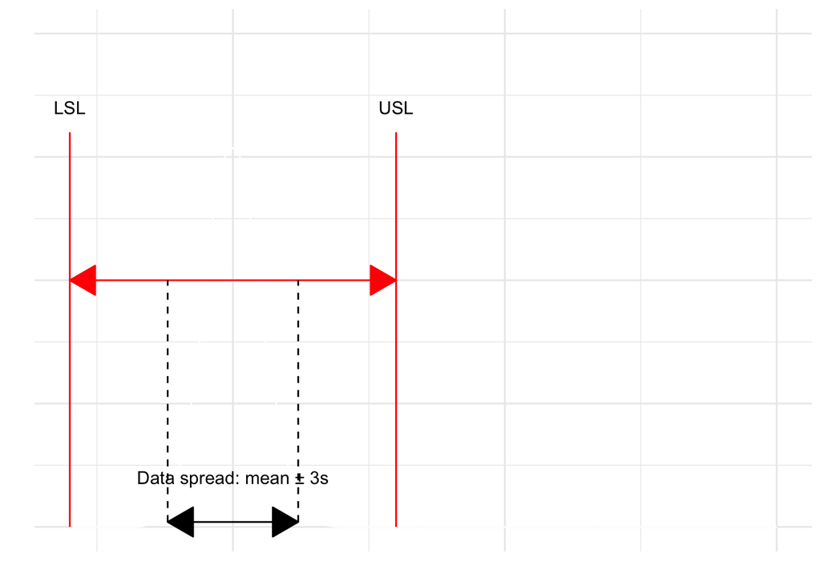

$Pp = \dfrac{(USL-LSL)}{6 \ s}$

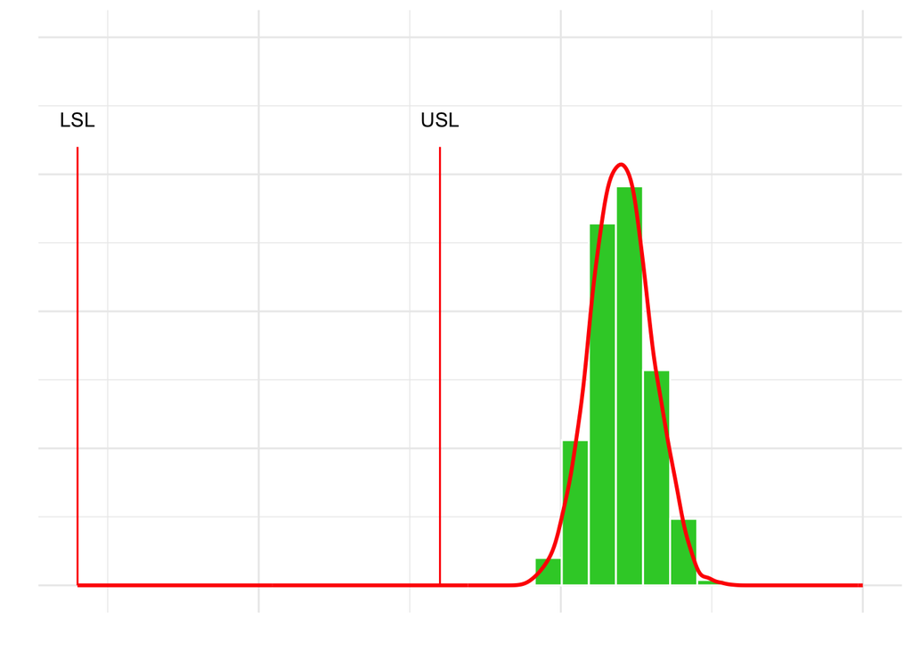

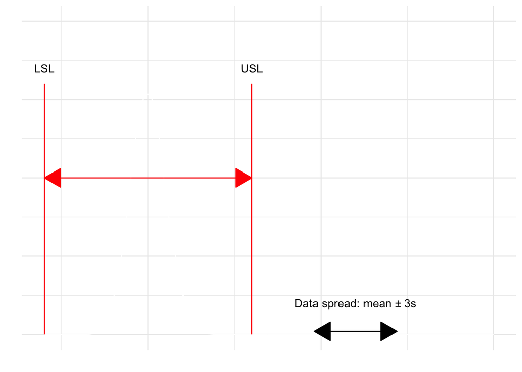

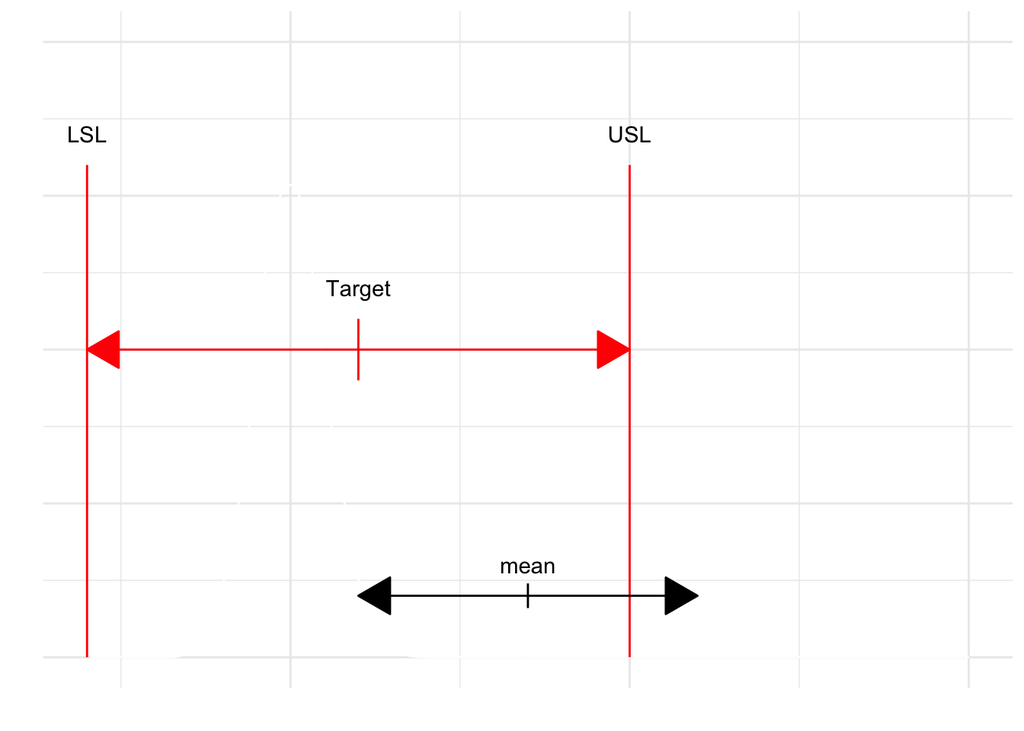

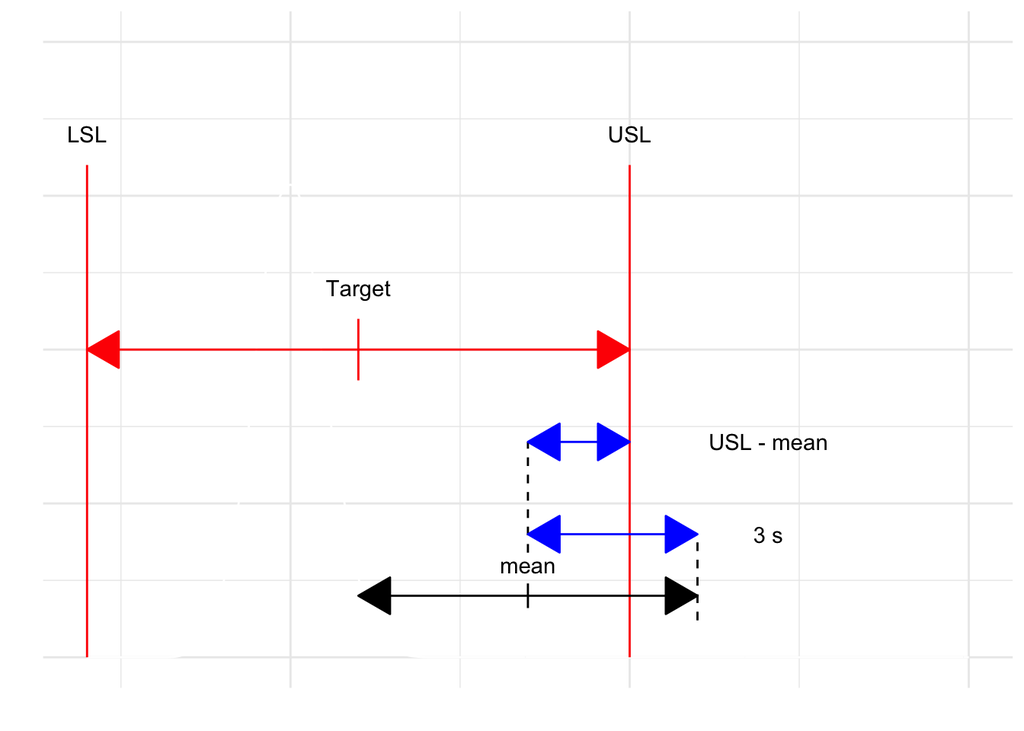

$Ppk = min[\dfrac{(USL-mean)}{3 \ s}; \dfrac{(mean-LSL)}{3 \ s}]$

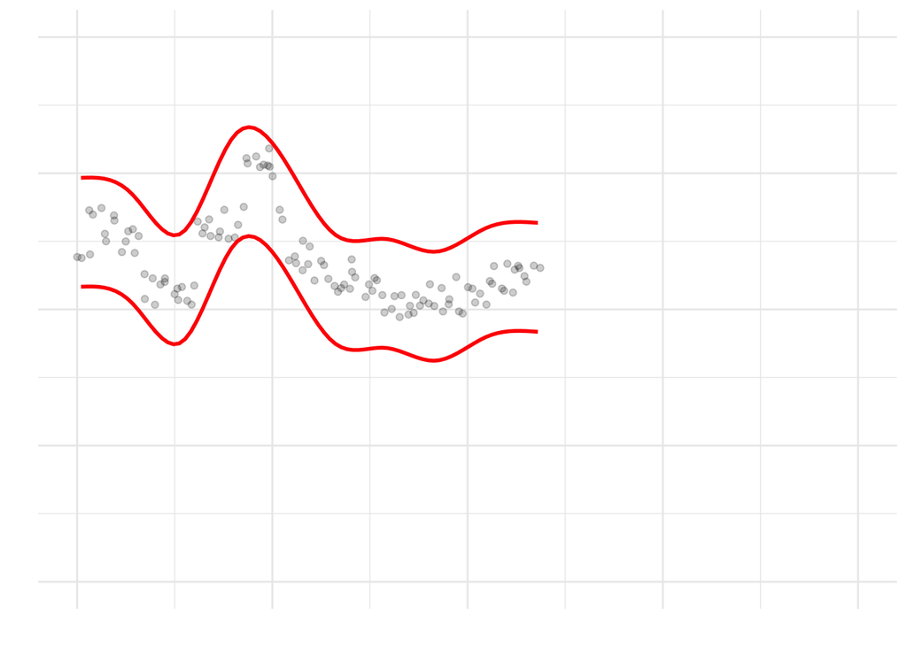

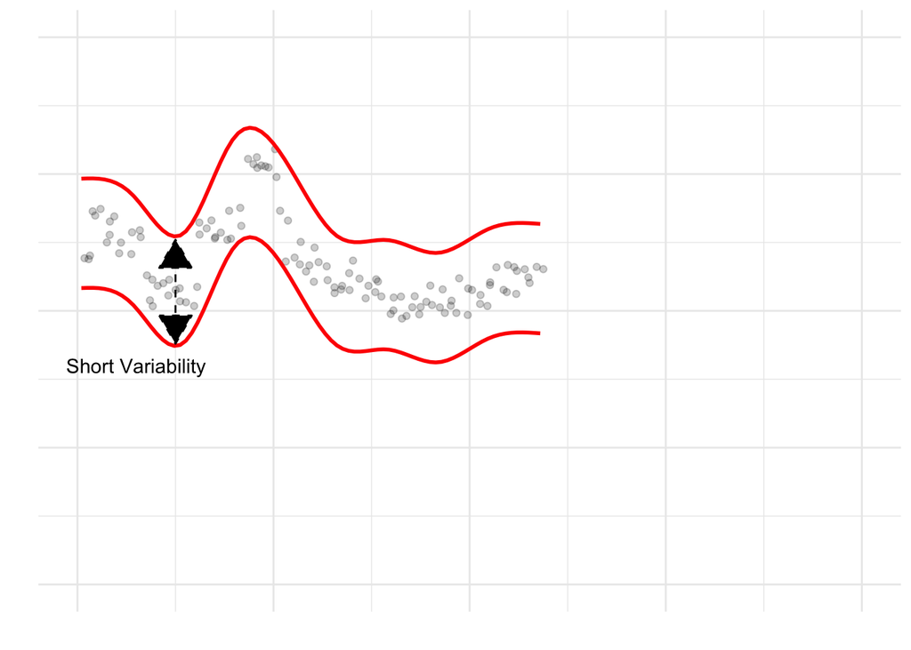

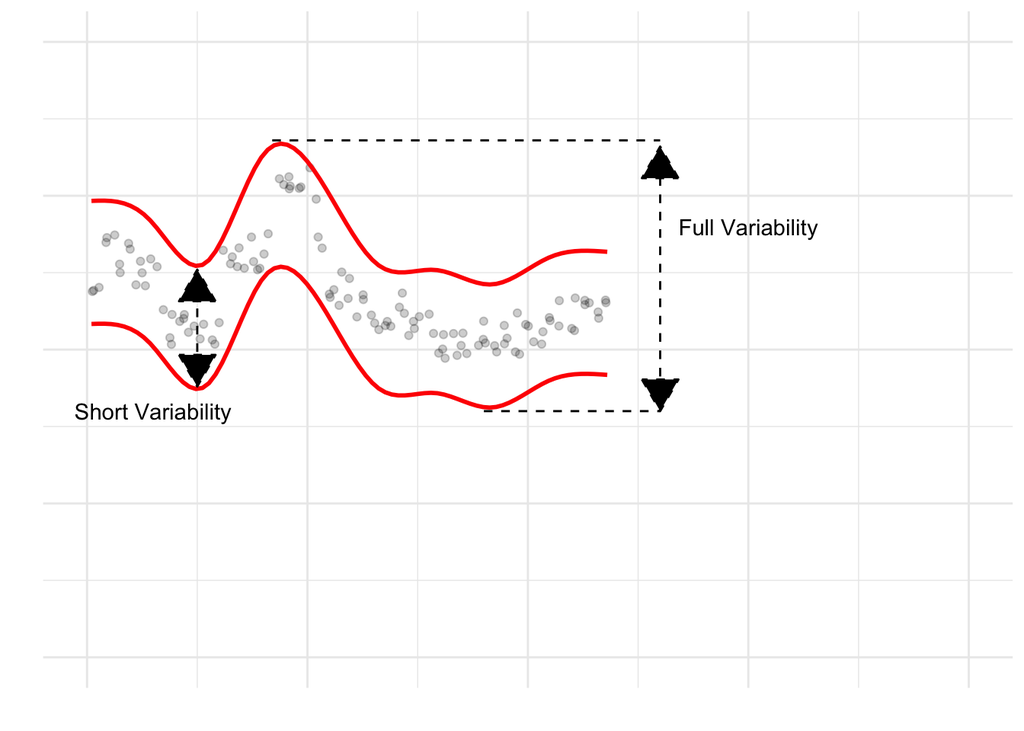

$Cp = \dfrac{(LS-LI)}{6 \ s^{MR}}$

$Cpk = min[\dfrac{(USL-mean)}{3 \ s^{MR}}; \dfrac{(mean-LSL)}{3 \ s^ {MR}}]$

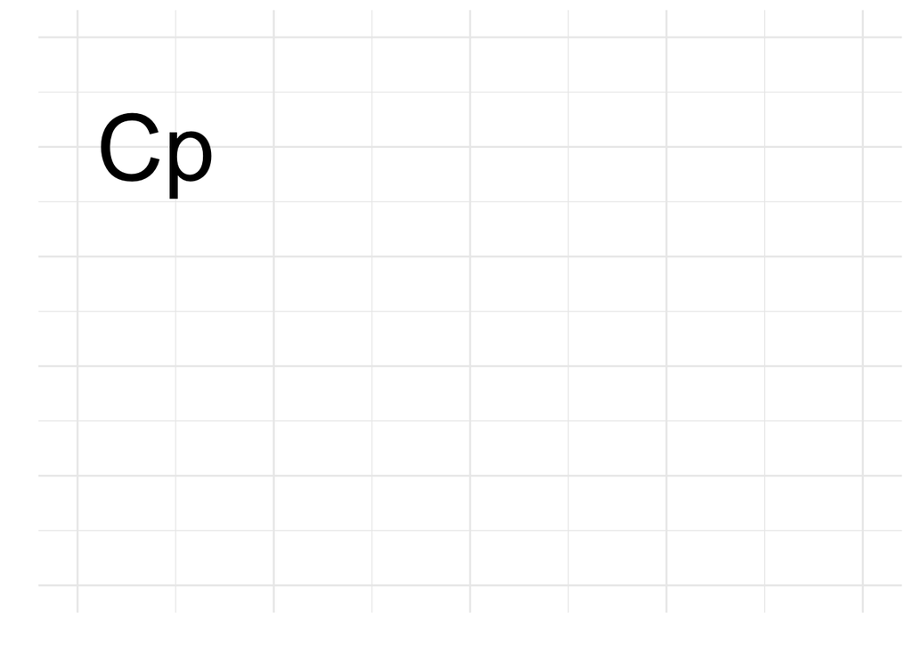

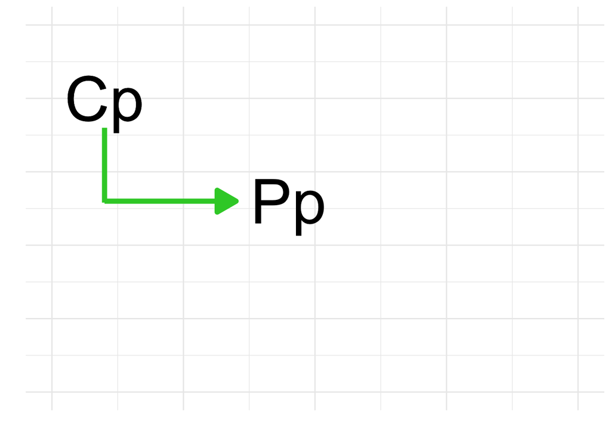

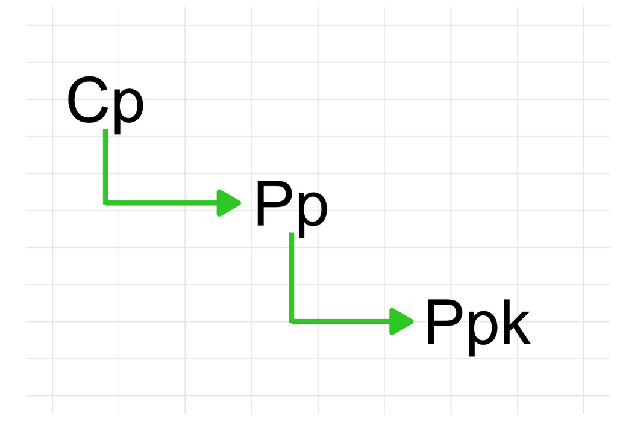

$Cp > Pp > Ppk$

Author: gmo date: 2025-07-07